# Exploring the Airbnb Listings in New York City: An Exploratory Data Analysis

Project 1 - MAT214

Joel Joseph Jaison

2023-03-21

# Description:

The Airbnb dataset is a collection of information on Airbnb listings and reviews from various cities around in New York.The dataset is commonly used for data analysis and visualization to gain insights into the pricing, popularity, and performance of Airbnb listings in different areas.

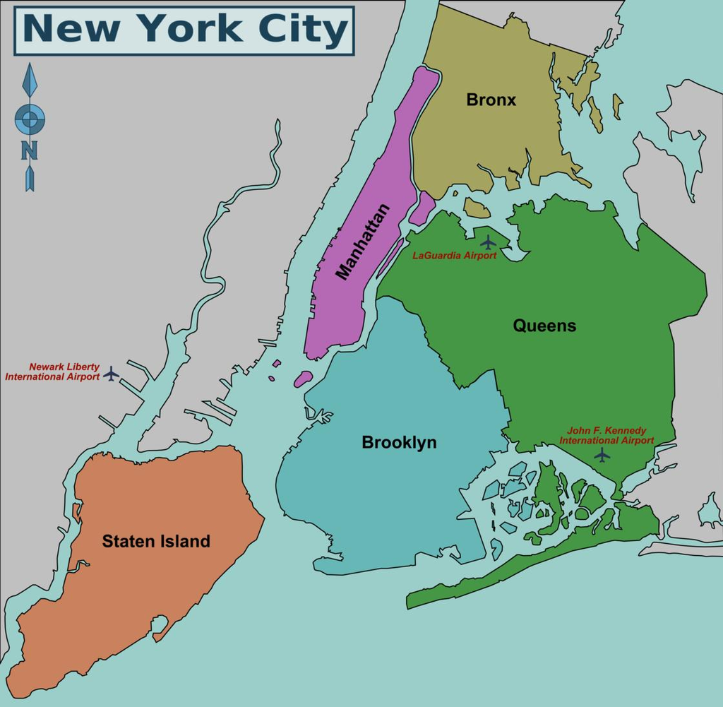

Figure 1: Map of New York City with the five boroughs (1)

# Reflective of the Project:

The objective of this project is to conduct an exploratory data analysis (EDA) of a chosen dataset that satisfies specific data requirements. The EDA will involve loading and parsing the data into R, visualizing and exploring the variation in the variables, identifying typical and unusual values, and investigating covariation between the variables. The project will also involve generating questions about the dataset to guide further analysis.

### Format:

| Variables | Description |
| --- | --- |
| id | ID number of the listing |
| name | Name of the listing |
| host_id | ID number of the host |
| host_name | Name of the host |
| neighbourhood_group | Boroughs in which the listing is located |
| neighbourhood | Neighborhood in which the listing is located |
| latitude | Latitude of the listing |
| longitude | Longitude of the listing |
| room_type | Type of room (e.g. Entire home/apt, Private room) |
| price | Price per night |
| minimum_nights | Minimum number of nights for a stay |
| number_of_reviews | Number of reviews for the listing |
| last_review | Date of the latest review |
| reviews_per_month | Number of reviews per month |
| calculated_host_listings_count | Number of listings by the same host |
| availability_365 | Number of days in the year that the listing is available |

### Source:

https://www.kaggle.com/datasets/dgomonov/new-york-city-airbnb-open-data

# Task 1:

### 1.Parsing Data

```r
airbnb <- read.csv("C:/Users/joelj/OneDrive/Desktop/AB_NYC_2019.csv")
```

This line of code loads the data stored in the file “AB_NYC_2019.csv” into R as a dataframe and assigns it to the variable name “airbnb”.This line of code assumes that our data set is in .csv format. The filepath of the file is specified as “C:/Users/joelj/OneDrive/Desktop/” and may need to be adjusted depending on where the file is located on the user’s computer. Once loaded, the data can be manipulated and analyzed using various R functions and packages.

### 2. Requirements

```r
str(airbnb)
```

```
## 'data.frame':    48895 obs. of  16 variables:
##  $ id                            : int  2539 2595 3647 3831 5022 5099 5121 5178 5203 5238 ...
##  $ name                          : chr  "Clean & quiet apt home by the park" "Skylit Midtown Castle" "THE VILLAGE OF HARLEM....NEW YORK !" "Cozy Entire Floor of Brownstone" ...
##  $ host_id                       : int  2787 2845 4632 4869 7192 7322 7356 8967 7490 7549 ...
##  $ host_name                     : chr  "John" "Jennifer" "Elisabeth" "LisaRoxanne" ...
##  $ neighbourhood_group           : chr  "Brooklyn" "Manhattan" "Manhattan" "Brooklyn" ...
##  $ neighbourhood                 : chr  "Kensington" "Midtown" "Harlem" "Clinton Hill" ...
##  $ latitude                      : num  40.6 40.8 40.8 40.7 40.8 ...
##  $ longitude                     : num  -74 -74 -73.9 -74 -73.9 ...
##  $ room_type                     : chr  "Private room" "Entire home/apt" "Private room" "Entire home/apt" ...
##  $ price                         : int  149 225 150 89 80 200 60 79 79 150 ...
##  $ minimum_nights                : int  1 1 3 1 10 3 45 2 2 1 ...
##  $ number_of_reviews             : int  9 45 0 270 9 74 49 430 118 160 ...
##  $ last_review                   : chr  "2018-10-19" "2019-05-21" "" "2019-07-05" ...
##  $ reviews_per_month             : num  0.21 0.38 NA 4.64 0.1 0.59 0.4 3.47 0.99 1.33 ...
##  $ calculated_host_listings_count: int  6 2 1 1 1 1 1 1 1 4 ...
##  $ availability_365              : int  365 355 365 194 0 129 0 220 0 188 ...
```

```r
table(airbnb$neighbourhood_group)
```

```
##
##         Bronx      Brooklyn     Manhattan        Queens Staten Island
##          1091         20104         21661          5666           373
```

Using the str() function , we can see the structure of the dataset. Here we can see that:

1. There is 48895 observations.
2. There are 3 numerical variables which are latitude, longitude and reviews_per_month
3. There are 2 categorical variables which are neighbourhood_group and room_type
4. There are 16 variables in total

Additionally , We see that the variable last_review consists of dates

Therefore this dataset, satisfies all our requirements

# Task 2:

### 1. Plots of Variation of Variables

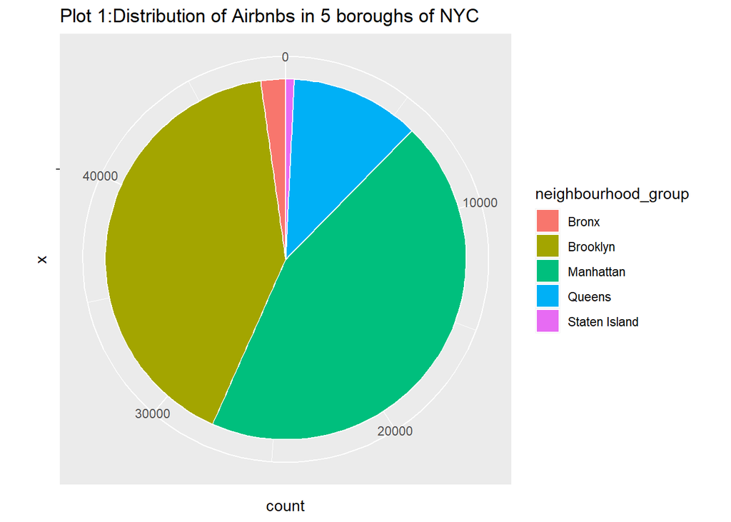

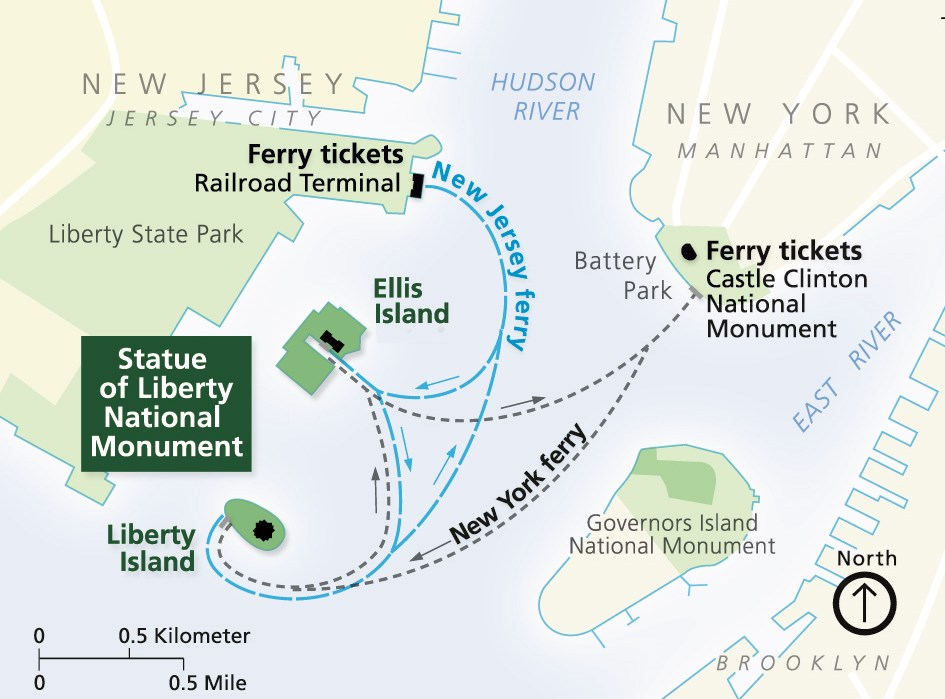

Figure 2: Ferry Map of New York City (2)

[figure not shown]

Figure 3: Map with the most famous attractions in New York City(3)

This is a polar bar chart which provides a visualization of the distribution of airbnb listings in New York City. Manhattan has the largest number of airbnb listing among all the neighbourhoods. It was found from Figure 2 that Manhattan is one of the closest borough in New York which has easy access to the Statue of Liberty which is one of the most famous attractions in The United States. And from Figure 3 we can see that Manhattan has other important attractions like the Empire State Building, Rockfeller Center and even includes Times Square where about 330,000 people pass through it on a daily basis(4). We also see that distribution in Brooklyn is almost equal to that of Manhattan, this is because Brooklyn has some famous attractions like the Brooklyn Bridge (Figure 3). But surely other factors like Low Seasonality, Lenient Airbnb Laws and Regulations,Access to Public Transportation and Amenities and many others could also be a factor to the distribution of airbnbs in NYC but in this project we focus on just the proximity to famous attractions(5)

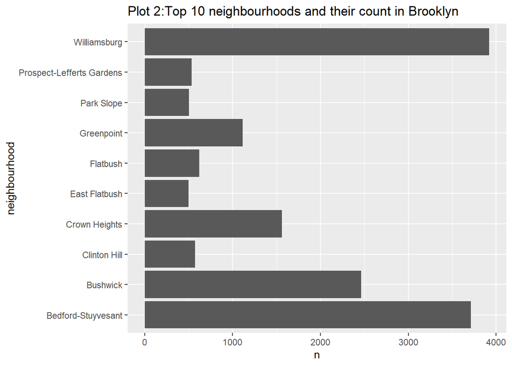